# EDA the Gaia DR3 Full Catalog

```python
# Basic Packages
import sys
import numpy as np
import pandas as pd
import matplotlib.pyplot as plt
from scipy.spatial import cKDTree
import gc

pd.options.display.max_rows = 200

# plot settings
plt.rc('font', family='serif')
plt.rc('font', serif='Times New Roman')
plt.rcParams.update({'font.size': 16})
plt.rcParams['mathtext.fontset'] = 'stix'
```

```python
# PySpark packages
from pyspark import SparkContext
from pyspark.sql import SQLContext
from pyspark.sql import SparkSession

sc = spark.sparkContext
sqlsc = SQLContext(sc)
sc.setCheckpointDir("hdfs://spark00:54310/tmp/checkpoints")

import pyspark.sql.functions as F
import pyspark.sql.types as T
from pyspark import Row
from pyspark.sql.window import Window as W
```

```python
spark.conf.set("spark.sql.execution.arrow.pyspark.enabled", "true")
```

## Read all sky data

```python
import pyarrow as pa
import pyarrow.parquet as pq
```

```python
filepath = \
"hdfs://spark00:54310/common/data/catalog/external-catalogs/parquet/gaia-dr3/raw/"
```

#### Read all parquets at once

```python
%%time
# Read all parquets in the directory
rawdf = spark.read.option("header","true").option("recursiveFileLookup","true").parquet(filepath)
```

```
CPU times: user 1.45 ms, sys: 0 ns, total: 1.45 ms
Wall time: 2.92 s
```

## Select useful columns

```python
#rawdf.printSchema()
print(rawdf.columns)
```

```
['solution_id', 'designation', 'source_id', 'random_index', 'ref_epoch', 'ra', 'ra_error', 'dec', 'dec_error', 'parallax', 'parallax_error', 'parallax_over_error', 'pm', 'pmra', 'pmra_error', 'pmdec', 'pmdec_error', 'ra_dec_corr', 'ra_parallax_corr', 'ra_pmra_corr', 'ra_pmdec_corr', 'dec_parallax_co…
```

```python
df = rawdf.select('source_id','ra','dec','parallax','pm','pmra','pmdec', \
                  'astrometric_excess_noise','ruwe','classprob_dsc_combmod_quasar', \
                  'classprob_dsc_combmod_galaxy','classprob_dsc_combmod_star', \
                  'ra_error','dec_error','parallax_error','parallax_over_error','pmra_error','pmdec_error'
                 )
```

```python
df.cache()
```

```
DataFrame[source_id: bigint, ra: double, dec: double, parallax: double, pm: float, pmra: double, pmdec: double, astrometric_excess_noise: float, ruwe: float, classprob_dsc_combmod_quasar: float, classprob_dsc_combmod_galaxy: float, classprob_dsc_combmod_star: float, ra_error: float, dec_error: float…
```

```python
%%time
df.select('source_id','ra','dec','parallax').describe().toPandas().transpose()
```

```
CPU times: user 19.3 ms, sys: 10.1 ms, total: 29.4 ms
Wall time: 2min 36s
```

|  | 0 | 1 | 2 | 3 | 4 |
| --- | --- | --- | --- | --- | --- |
| summary | count | mean | stddev | min | max |
| source_id | 1811709771 | 4.3515610592999311E18 | 1.64011514434601754E18 | 4295806720 | 6917528997577384320 |
| ra | 1811709771 | 229.12434364249697 | 77.78510767878046 | 3.4096239126626443E-7 | 359.999999939548 |
| dec | 1811709771 | -18.374270531226486 | 36.53941026762338 | -89.99287859590359 | 89.99005196682685 |
| parallax | 1467744818 | 0.366361130476772 | 1.0261718025894793 | -187.02939637423492 | 768.0665391873573 |

> 1.8 billion objects !

## Raw Stellar Objects

```python
%%time
rawstardf = df.filter((F.col('classprob_dsc_combmod_star') > 0.5) & (F.col('ruwe') < 1.4))
```

```
CPU times: user 297 µs, sys: 404 µs, total: 701 µs
Wall time: 10.8 ms
```

```python
%%time
rawstardf.select('source_id','ra','dec').describe().toPandas().transpose()
```

```
CPU times: user 2.77 ms, sys: 3.29 ms, total: 6.06 ms
Wall time: 2.35 s
```

|  | 0 | 1 | 2 | 3 | 4 |
| --- | --- | --- | --- | --- | --- |
| summary | count | mean | stddev | min | max |
| source_id | 1304979431 | 4.3132475589375841E18 | 1.72159960843960781E18 | 4295806720 | 6917528997577384320 |
| ra | 1304979431 | 224.7829530609692 | 81.18003284199813 | 3.4096239126626443E-7 | 359.999999939548 |
| dec | 1304979431 | -16.595830099101708 | 38.30390216592705 | -89.99287859590359 | 89.99005196682685 |

> 1.3 billion stars !

## HealPix Visualization

> healpy: https://healpy.readthedocs.io/en/latest/tutorial.html  
> The choices of `nside` and projection method such as `mollview`(?) should be settled.

```python
import healpy as hp
```

```python
%time
rawstardf.limit(5).toPandas().transpose()
```

```
CPU times: user 1e+03 ns, sys: 1e+03 ns, total: 2 µs
Wall time: 3.58 µs
```

|  | 0 | 1 | 2 | 3 | 4 |
| --- | --- | --- | --- | --- | --- |
| source_id | 4.295807e+09 | 3.436113e+10 | 3.865554e+10 | 3.092381e+11 | 3.435974e+11 |
| ra | 4.499616e+01 | 4.500432e+01 | 4.500498e+01 | 4.499504e+01 | 4.496390e+01 |
| dec | 5.615226e-03 | 2.104776e-02 | 1.987968e-02 | 3.815170e-02 | 4.359494e-02 |
| parallax | 3.543306e-01 | 3.235017e+00 | 3.139170e+00 | 1.383150e+00 | 1.961477e-01 |
| pm | 1.261648e+01 | 3.523051e+01 | 3.530821e+01 | 1.472751e+00 | 6.845276e+00 |
| pmra | 1.193835e+01 | 2.951834e+01 | 2.968634e+01 | 7.103391e-01 | 6.567299e+00 |
| pmdec | -4.080619e+00 | 1.923165e+01 | 1.911520e+01 | -1.290122e+00 | -1.930905e+00 |
| astrometric_excess_noise | 3.806193e-01 | 2.674134e-01 | 0.000000e+00 | 0.000000e+00 | 0.000000e+00 |
| ruwe | 1.142952e+00 | 1.057890e+00 | 1.012191e+00 | 9.856941e-01 | 9.789714e-01 |
| classprob_dsc_combmod_quasar | 3.035489e-11 | 1.082019e-13 | 1.039826e-13 | 3.476444e-10 | 2.770367e-11 |
| classprob_dsc_combmod_galaxy | 7.045791e-13 | 5.682676e-13 | 5.193881e-13 | 5.879542e-10 | 5.131301e-13 |
| classprob_dsc_combmod_star | 9.999876e-01 | 9.993886e-01 | 9.998059e-01 | 9.999797e-01 | 9.999906e-01 |
| ra_error | 1.016183e-01 | 9.731972e-02 | 1.788540e-02 | 3.220395e-01 | 1.171760e-01 |
| dec_error | 1.013339e-01 | 1.017530e-01 | 1.877158e-02 | 2.835049e-01 | 1.090039e-01 |
| parallax_error | 1.226638e-01 | 1.204503e-01 | 2.234741e-02 | 3.679067e-01 | 1.334645e-01 |
| parallax_over_error | 2.888632e+00 | 2.685770e+01 | 1.404713e+02 | 3.759512e+00 | 1.469662e+00 |
| pmra_error | 1.379423e-01 | 1.336928e-01 | 2.377173e-02 | 4.276462e-01 | 1.545800e-01 |
| pmdec_error | 1.331698e-01 | 1.339218e-01 | 2.383038e-02 | 3.647294e-01 | 1.360506e-01 |

#### Basic Settings for HealPix

```python
NSIDE = 512
NPIX = hp.nside2npix(NSIDE)
print(NPIX)
```

```
3145728
```

> Still, I am exploring which `NSIDE` is the best for Gaia visualizations

#### UDF for getting HealPix indices

```python
import numpy as np
import healpy as hp
def getHealPixIndexLatLon(inlat, inlon, nside):
    lat_theta = 0.5*np.pi - np.radians(inlat)
    lon_phi = np.radians(inlon)
    #print("lat_theta/pi= ",lat_theta/np.pi)
    #print("lon_phi/pi= ",lon_phi/np.pi)

    return int(hp.ang2pix(nside,theta = lat_theta,phi= lon_phi,nest=True))
```

```python
from functools import partial
healpixudf = F.udf(partial(getHealPixIndexLatLon,nside=NSIDE),T.IntegerType())
```

#### Applying the healpix 512 nested to all `rawstardf`

```python
%%time
rawstardf = rawstardf.withColumn('ipx512nested',healpixudf(F.col('dec'),F.col('ra')))
```

```
CPU times: user 2.99 ms, sys: 0 ns, total: 2.99 ms
Wall time: 17.7 ms
```

```python
rawstardf.cache()
```

```
DataFrame[source_id: bigint, ra: double, dec: double, parallax: double, pm: float, pmra: double, pmdec: double, astrometric_excess_noise: float, ruwe: float, classprob_dsc_combmod_quasar: float, classprob_dsc_combmod_galaxy: float, classprob_dsc_combmod_star: float, ra_error: float, dec_error: float…
```

```python
%time
rawstardf['source_id','ra','dec','ipx512nested'].limit(3).toPandas().transpose()
```

```
CPU times: user 1 µs, sys: 0 ns, total: 1 µs
Wall time: 2.86 µs
```

|  | 0 | 1 | 2 |
| --- | --- | --- | --- |
| source_id | 1.351959e+17 | 1.351960e+17 | 1.351960e+17 |
| ra | 4.446955e+01 | 4.448767e+01 | 4.447735e+01 |
| dec | 3.052774e+01 | 3.053371e+01 | 3.054131e+01 |
| ipx512nested | 6.148000e+04 | 6.148000e+04 | 6.148000e+04 |

#### Groupby `ipx512nested` and count the stars in each `ipx512nested` group

```python
rawstarcountdf = rawstardf.groupBy('ipx512nested').agg(F.count("*").alias("count"))
```

#### Filling the missing groups with `zero`

```python
%%time
repdf = rawstarcountdf.orderBy('ipx512nested').toPandas().set_index('ipx512nested')
```

```
CPU times: user 71.2 ms, sys: 95 ms, total: 166 ms
Wall time: 3.66 s
```

```python
full_index = pd.RangeIndex(start=0, stop=NPIX)
```

```python
filledpdf = repdf.reindex(full_index, fill_value=0)
```

```
findfont: Font family ['serif'] not found. Falling back to DejaVu Sans.
findfont: Font family ['serif'] not found. Falling back to DejaVu Sans.
```

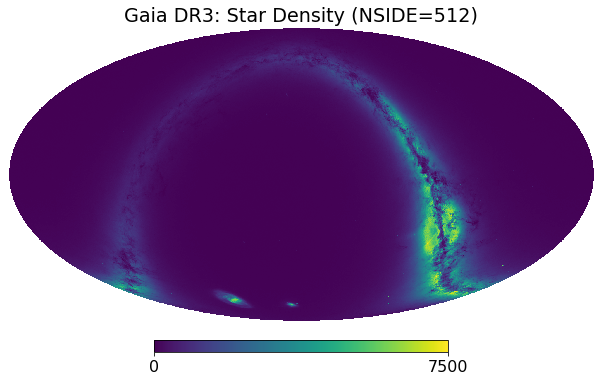

```python
hp.mollview(filledpdf['count'].values,nest=True,title='Gaia DR3: Star Density (NSIDE=512)',xsize=2000)
```

### Assigning Galactic Coordinates

#### Testing UDF for getting Galactic coordinates

```python
from astropy.coordinates import SkyCoord
import astropy.units as u
def getGalacticCoordinates(inra,indec):
    tmp_eclip = SkyCoord(inra * u.deg,indec * u.deg,frame='barycentrictrueecliptic')
    tmp_gal = tmp_eclip.transform_to('galactic')
    #print("lat_theta/pi= ",lat_theta/np.pi)
    #print("lon_phi/pi= ",lon_phi/np.pi)

    return [float(tmp_gal.l.value),float(tmp_gal.b.value)]
```

```python
## Define UDF for pyspark
galcoordudf = F.udf(getGalacticCoordinates ,T.ArrayType(T.DoubleType()))
```

```python
getGalacticCoordinates(61.181783,16.360603)
```

```
[156.93869947124142, -15.160067971564013]
```

# `Skycoord` is a heavy class, not good for massive big data calculation. This seems to be a *serious* problem in astropy.

> [1]Let's first try other package which has some light version of coordinate coverters.  
> [2] Or, follow this webpage for writing down my own:  
> https://astrophysicsandpython.com/2021/04/19/celestial-coordinate-conversions/  
> https://en.wikipedia.org/wiki/Galactic_coordinate_system  
> https://casper.astro.berkeley.edu/astrobaki/index.php/Coordinates

#### Let's try the `casper berkeley` method

```python
import numpy as np
eclgalmat = np.array([ \
                      [-0.054876, -0.873437, -0.483835],\
                      [0.494109, -0.444830, 0.746982],\
                      [-0.867666, -0.198076, 0.455984]\
                     ])
def fast_ecl2gal_deg(radeg,decdeg,rotmat=eclgalmat):
    rarad, decrad = np.radians([radeg,decdeg])
    invec = np.array([np.cos(decrad)*np.cos(rarad),np.cos(decrad)*np.sin(rarad),np.sin(decrad)])
    x0,x1,x2 = np.dot(rotmat,invec)

    #python's builit float is double-precision
    return [float(np.degrees(np.arctan2(x1,x0))),float(np.degrees(np.arcsin(x2)))]
```

```python
fast_ecl2gal_deg(61.181783,16.360603)
```

```
[175.85144397081916, -26.064512016159252]
```

#### Let's try the `astrophysicsandpython.com` method

```python
## prerequisite variables
_ecliptic = np.radians(23.43927944)
#_ra_gal, _dec_gal, _long_ncp = np.radians([192.85948, 27.12825, 122.93192])
```

```python
def equatorial_to_galactic(right_ascension, declination, \
                           _ra_gal=3.3660329196841534, _dec_gal=0.47347728280415174, _long_ncp=2.1455667597982675):
    ra, dec = np.radians(right_ascension), np.radians(declination)

    gal_lat = np.sin(dec) * np.sin(_dec_gal)
    gal_lat = np.arcsin(gal_lat + np.cos(dec) * np.cos(_dec_gal) * np.cos(ra - _ra_gal))

    gal_longa = np.cos(dec) * np.sin(ra - _ra_gal)
    gal_longb = np.sin(dec) * np.cos(_dec_gal)
    gal_longb = gal_longb - np.cos(dec) * np.sin(_dec_gal) * np.cos(ra - _ra_gal)
    gal_long = _long_ncp - np.arctan2(gal_longa,gal_longb)

    gal_long, gal_lat = np.degrees([gal_long, gal_lat])

    return [float(gal_long), float(gal_lat)]
```

```python
equatorial_to_galactic(61.181783, 16.360603)
```

```
[175.8514066426282, -26.064540457110425]
```

```python
## Define UDF for pyspark
galcoordfastudf = F.udf(equatorial_to_galactic ,T.ArrayType(T.DoubleType()))
```

> Weird.. the `Skycoord` result is different from the others.

#### Applying UDF for getting Galactic coordinates

#### `galcoordudf` vs. `galcoordfastudf`

```python
%%time
rawstardf = rawstardf.withColumn('tmp_gal_coord',galcoordfastudf(F.col('ra'),F.col('dec')))
#rawstardf = rawstardf.withColumn('tmp_gal_coord',galcoordudf(F.col('ra'),F.col('dec')))
rawstardf = rawstardf.withColumn('gal_l',F.col('tmp_gal_coord').getItem(0).cast("double"))
rawstardf = rawstardf.withColumn('gal_b',F.col('tmp_gal_coord').getItem(1).cast("double"))
rawstardf = rawstardf.drop(F.col('tmp_gal_coord'))
```

```
CPU times: user 3.59 ms, sys: 0 ns, total: 3.59 ms
Wall time: 29.1 ms
```

```python
#%%time
#rawstardf.collect()
```

> First, I got an error message related to `spark.driver.maxResultSize`.  
> I put this option when I launch the spark shell `--conf spark.driver.maxResultSize=32g`  
> **Beware: Collect is a dangerous command, since it collect all data to the master(driver) node. If the data size is much larger than the master's physical memory, you should save the data to a file in hdfs, not collecting to your master(driver) node.**

#### Adding healpix ids for galactic coordinates

```python
NSIDE = 512
NPIX = hp.nside2npix(NSIDE)
print(NPIX)
```

```
3145728
```

```python
import numpy as np
import healpy as hp
def getHealPixIndexLatLon(inlat, inlon, nside):
    lat_theta = 0.5*np.pi - np.radians(inlat)
    lon_phi = np.radians(inlon)
    #print("lat_theta/pi= ",lat_theta/np.pi)
    #print("lon_phi/pi= ",lon_phi/np.pi)

    return int(hp.ang2pix(nside,theta = lat_theta,phi= lon_phi,nest=True))
```

```python
from functools import partial
healpixudf = F.udf(partial(getHealPixIndexLatLon,nside=NSIDE),T.IntegerType())
```

```python
rawstardf = rawstardf.withColumn('gal_ipx512nested',healpixudf(F.col('gal_b'),F.col('gal_l')))
```

```python
rawstardf.cache()
```

```
DataFrame[source_id: bigint, ra: double, dec: double, parallax: double, pm: float, pmra: double, pmdec: double, astrometric_excess_noise: float, ruwe: float, classprob_dsc_combmod_quasar: float, classprob_dsc_combmod_galaxy: float, classprob_dsc_combmod_star: float, ra_error: float, dec_error: float…
```

#### Write the reduced `rawstardf` as a parquet in hdfs

```python
outfilename = \
"hdfs://spark00:54310/common/data/catalog/external-catalogs/parquet/gaia-dr3/reduced/rawstar.parquet.snappy"
```

```python
%%time
rawstardf.write.option("compression", "snappy").mode("overwrite").save(outfilename)
```

```
CPU times: user 221 ms, sys: 250 ms, total: 472 ms
Wall time: 11min 41s
```

#### Visualizing in Galactic Coordinates

```python
galrawstarcountdf = rawstardf.groupBy('gal_ipx512nested').agg(F.count("*").alias("count"))
```

```python
full_index = pd.RangeIndex(start=0, stop=NPIX)
```

```python
%%time
tmppdf = \
galrawstarcountdf.orderBy('gal_ipx512nested').toPandas()\
.set_index('gal_ipx512nested').reindex(full_index, fill_value=0)
```

```
CPU times: user 121 ms, sys: 122 ms, total: 243 ms
Wall time: 2.78 s
```

> The running time for `galcoordfastudf` is `12min`,  
> while `galcoordudf` 6 hours

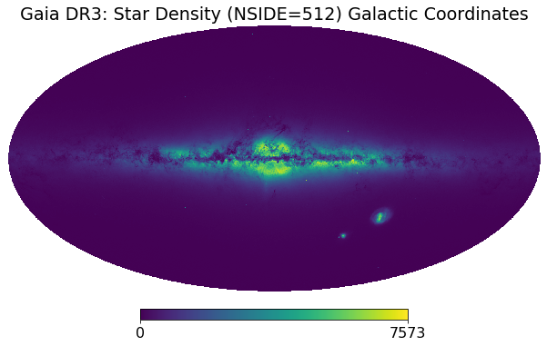

```python
hp.mollview(tmppdf['count'].values,nest=True, \
            title='Gaia DR3: Star Density (NSIDE=512) Galactic Coordinates', \
            xsize=2000)
```